# 1-data-visualization

Thank you to [R for Data Science (2e)](https://r4ds.hadley.nz/data-visualize.html) for this learning experience.

*Creator: Kevin Zhou*

## Starting Out

```r
# libs to import
library(tidyverse)
# Performing experiments with penguins dataset

# Would usually use glimpse(), but in RStudio use View()
# View(penguins)
head(penguins) #first few lines
```

|  | species | island | bill_len | bill_dep | flipper_len | body_mass | sex | year |
| --- | --- | --- | --- | --- | --- | --- | --- | --- |
| 1 | Adelie | Torgersen | 39.1 | 18.7 | 181 | 3750 | male | 2007 |
| 2 | Adelie | Torgersen | 39.5 | 17.4 | 186 | 3800 | female | 2007 |
| 3 | Adelie | Torgersen | 40.3 | 18.0 | 195 | 3250 | female | 2007 |
| 4 | Adelie | Torgersen | NA | NA | NA | NA | NA | 2007 |
| 5 | Adelie | Torgersen | 36.7 | 19.3 | 193 | 3450 | female | 2007 |
| 6 | Adelie | Torgersen | 39.3 | 20.6 | 190 | 3650 | male | 2007 |

```r
# Verify device is still active
dev.cur()
```

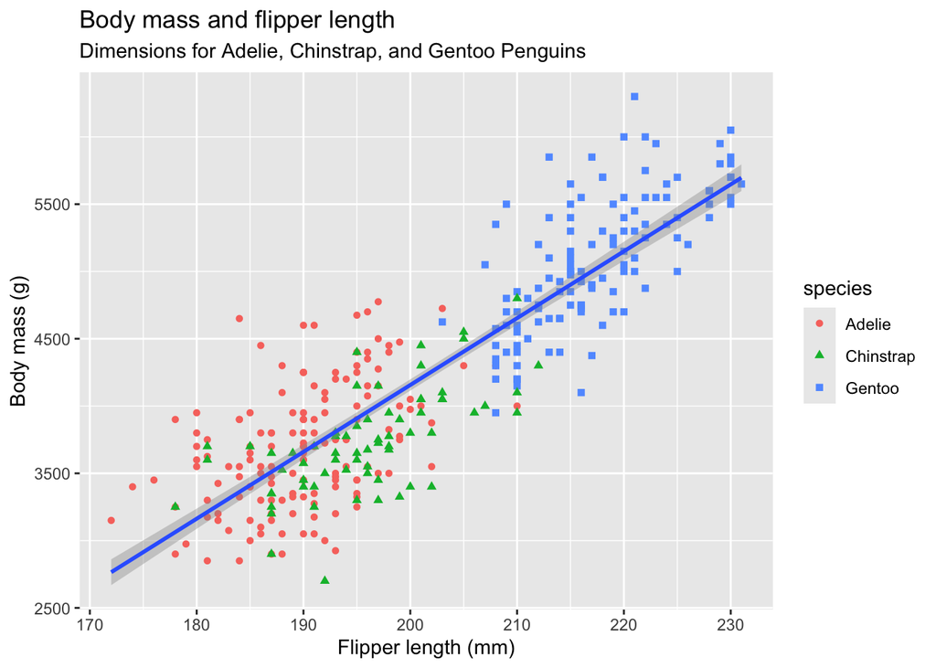

```r
# Goal: find the correlation between body mass (g) and flipper length.

# Utilizing ggplot() for blank graph (canvas)
# mapping argument -> always defined in aes() function
# aes() function specify which variables to map to x & y axes

# We can also color code different traits in a table -> scaling

ggplot(data = penguins, mapping = aes(x = flipper_len, y = body_mass)) +
  geom_point(mapping = aes(color = species, shape = species)) + # adds points to plot
  #creates scatterplot, mapping different shape and color to each species.
  geom_smooth(method = "lm") +  #linear regression
  labs( #improve labels on our graph by using this layer
    title = "Body mass and flipper length",
    subtitle = "Dimensions for Adelie, Chinstrap, and Gentoo Penguins",
    x = "Flipper length (mm)", y = "Body mass (g)",
  ) #+
```

```r
  #scale_color_colorblind() #making color palette color-blind proof
```

### 1.2 Exercises (Unfinished)

##### 1.

344 Rows, 8 Columns

```r
dim(penguins)
```

```
## [1] 344   8
```

##### 2.

Denoting bill depth in milimeters

##### 3.

- Slight negative linear correlation across all species.
- Within individual species, slight positive linear correlation between bill length and depth.

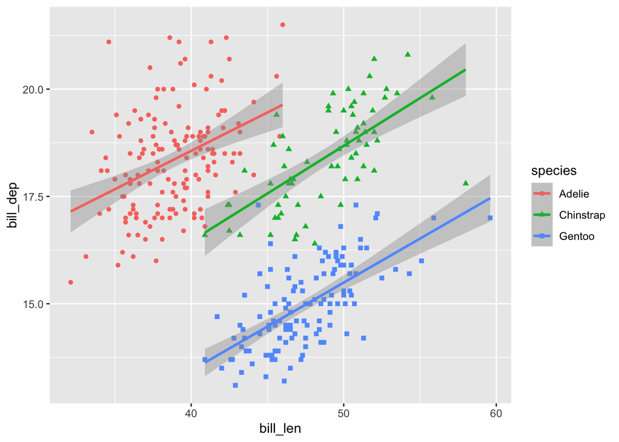

```r
ggplot(
  data = penguins,
  mapping = aes(x = bill_len, y = bill_dep, color = species) #add color = species for
  #linearization of individual species
) +
  geom_point(mapping = aes(color = species, shape = species)) +
  geom_smooth(method = "lm")
```

##### 4.

Better choice of geom would be to find a quantifiable trait of penguins that spans across all species instead of putting a categorical variable that is the species in the x value.

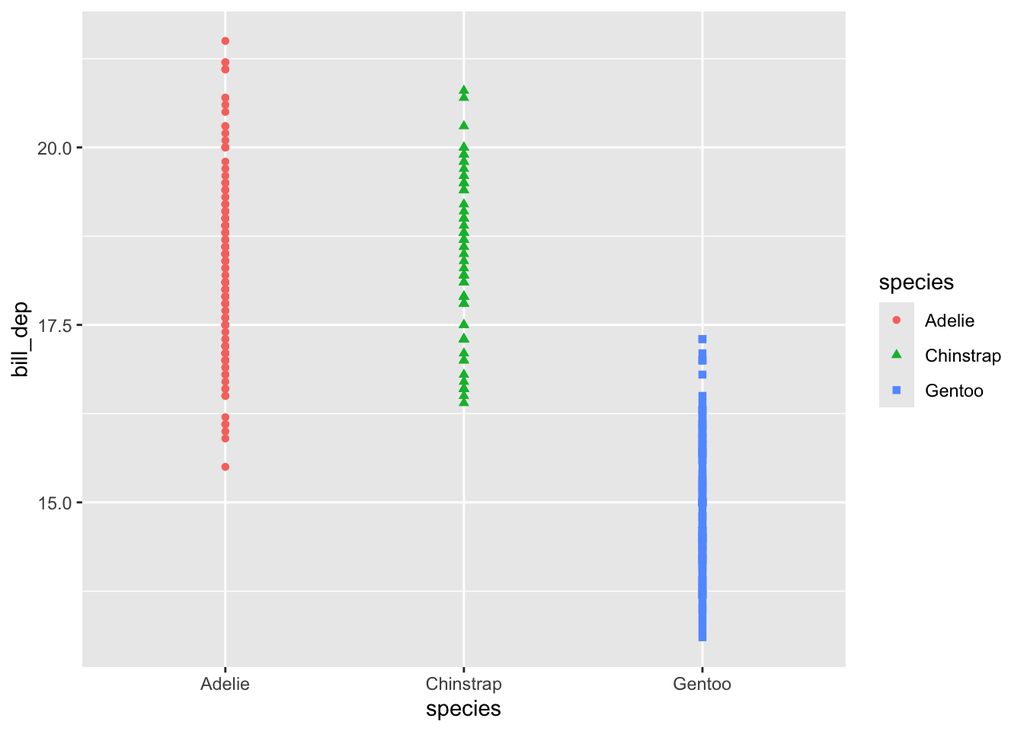

```r
ggplot(
  data = penguins,
  mapping = aes(x = species, y = bill_dep) #add color = species for
  #linearization of individual species
) +
  geom_point(mapping = aes(color = species, shape = species)) +
  geom_smooth(method = "lm")
```

##### 5.

```r
#ggplot(data = penguins) +
  #geom_point()
```

The above code gives an error because the x and the y-variables are not defined.